# Data exploration and deterministic functions

Analysis of Environmental Data 602

Emma Zimmerman Greenlee

2021-09-16

# Question 1

```r
require("here")
```

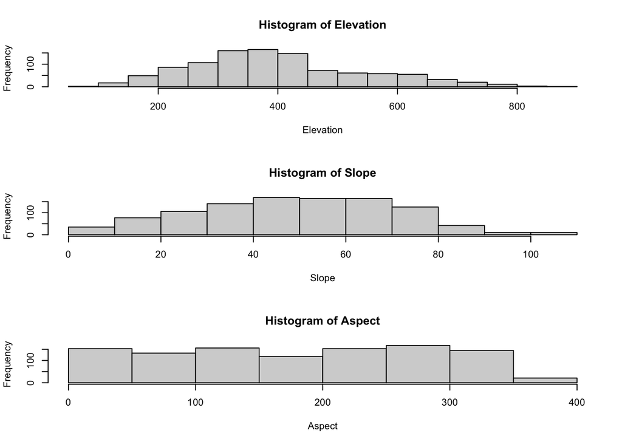

```r
dat_habitat = data.frame(read.csv(here("data", "hab.sta.csv")))

par(mfrow = c(3, 1))

hist(dat_habitat$elev, main = "Histogram of Elevation", xlab = "Elevation")

hist(dat_habitat$slope, main = "Histogram of Slope", xlab = "Slope")

hist(dat_habitat$aspect, main = "Histogram of Aspect", xlab = "Aspect")
```

# Question 2

The shape starts low and quickly gets taller and then drops off and tapers to an end as it gets higher. It is not evenly distributed, there are quite a bit more low elevation sampling sites

# Question 3

It’s measured in percent slope.

# Question 4

The data goes up like a staircase and then plateaus for a bit and then quickly goes down. The sample sites are definitely not mostly flat, they are mostly steep slopes. There are not many shallow slopes.

# Question 5

Aspect is the orientation of a location/what direction an object is facing using the 360 degrees of a circle.

# Question 6

The shape of the aspect histogram is mostly even all the way across, with a sharp drop at the very end. Becuase the sampling sites are pretty evenly distributed they are all (more or less) equally facing each side.